# Comparative Analysis of Generalized Kumaraswamy Family Distributions

07 abril, 2025

## Executive Summary

This report presents a comparative analysis of Generalized Kumaraswamy (GKw) family distributions fitted to the data. The analysis includes comparison of information criteria, goodness-of-fit tests, and diagnostic visualizations.

### Key Findings

- **Best Model**: kw
- **Total Observations**: 44
- **AIC Value of Best Model**: -49.1
- **BIC Value of Best Model**: -45.54

## Descriptive Statistics of the Data

| Statistic | Value |
| --- | --- |
| Minimum | 0.4593 |
| First Quartile | 0.6185 |
| Median | 0.7059 |
| Mean | 0.7728 |
| Third Quartile | 0.9900 |
| Maximum | 0.9900 |
| Standard Deviation | 0.1790 |
| Skewness | 0.0965 |
| Kurtosis | 1.3722 |

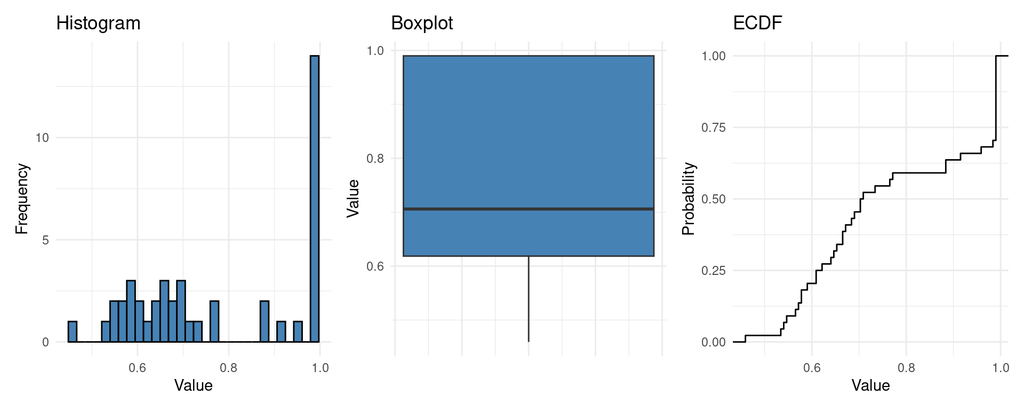

## Model Comparison

### Information Criteria

|  | Family | Parameters | Log-Likelihood | AIC | BIC | AICc |
| --- | --- | --- | --- | --- | --- | --- |
| kw | kw | 2 | 26.5518 | -49.1035 | -45.5352 | -48.8109 |
| ekw | ekw | 3 | 26.8664 | -47.7328 | -42.3802 | -47.1328 |
| kkw | kkw | 4 | 27.1362 | -46.2724 | -39.1356 | -45.2467 |
| bkw | bkw | 4 | 26.7191 | -45.4383 | -38.3015 | -44.4127 |
| gkw | gkw | 5 | 27.4216 | -44.8431 | -35.9222 | -43.2642 |
| beta | beta | 2 | 22.5398 | -41.0795 | -37.5111 | -40.7868 |
| mc | mc | 3 | 22.5764 | -39.1528 | -33.8002 | -38.5528 |

### Model Weights

|  | Family | AIC Weight | BIC Weight |
| --- | --- | --- | --- |
| kw | kw | 0.4877 | 0.7673 |
| ekw | ekw | 0.2457 | 0.1584 |
| kkw | kkw | 0.1184 | 0.0313 |
| bkw | bkw | 0.0780 | 0.0206 |
| gkw | gkw | 0.0579 | 0.0063 |
| beta | beta | 0.0088 | 0.0139 |
| mc | mc | 0.0034 | 0.0022 |

### Goodness-of-Fit Tests

|  | Family | KS Statistic | KS p-value | AD Statistic | AD p-value | CvM Statistic | CvM p-value |
| --- | --- | --- | --- | --- | --- | --- | --- |
| kw | kw | 0.2370 | 0.0143 | 3.8167 | 3e-04 | 0.6228 | 0.4274 |
| ekw | ekw | 0.2287 | 0.0200 | 3.4876 | 6e-04 | 0.5726 | 0.4466 |
| kkw | kkw | 0.2177 | 0.0309 | 3.3236 | 8e-04 | 0.5332 | 0.4627 |
| bkw | bkw | 0.2298 | 0.0192 | 3.5312 | 5e-04 | 0.5793 | 0.4440 |
| gkw | gkw | 0.2132 | 0.0366 | 3.2709 | 9e-04 | 0.5201 | 0.4683 |
| beta | beta | 0.2685 | 0.0035 | 6.9453 | 0e+00 | 0.7620 | 0.3800 |
| mc | mc | 0.2684 | 0.0035 | 6.9451 | 0e+00 | 0.7629 | 0.3797 |

### Additional Fit Metrics

|  | Family | Mean Absolute Error | Maximum Absolute Error | Mean Squared Error | Wasserstein Distance |
| --- | --- | --- | --- | --- | --- |
| 1 | gkw | 0.091201 | 0.213235 | 0.012301 | 0.054847 |
| 3 | kkw | 0.092626 | 0.217716 | 0.012633 | 0.058079 |
| 4 | ekw | 0.096423 | 0.228702 | 0.013655 | 0.062737 |
| 2 | bkw | 0.096927 | 0.229822 | 0.013810 | 0.063145 |
| 6 | kw | 0.100346 | 0.236974 | 0.014820 | 0.066145 |
| 7 | beta | 0.109553 | 0.245791 | 0.017359 | 0.059881 |
| 5 | mc | 0.109617 | 0.245722 | 0.017384 | 0.059925 |

## Estimated Parameters

|  | Family | alpha | beta | gama | delta | lambda |
| --- | --- | --- | --- | --- | --- | --- |
| kw | kw | 2.6832 | 0.6642 | NA | NA | NA |
| ekw | ekw | 7.6263 | 0.5563 | NA | NA | 0.3835 |
| kkw | kkw | 7.1186 | 0.2046 | NA | 1.1175 | 0.4616 |
| bkw | bkw | 6.2319 | 0.3760 | 0.4654 | 0.4608 | NA |
| gkw | gkw | 6.0103 | 0.1103 | 3.1261 | 2.2475 | 0.2245 |
| beta | beta | NA | NA | 3.6555 | 0.0500 | NA |
| mc | mc | NA | NA | 1.7999 | 0.0500 | 2.0216 |

|  | Family | SE(alpha) | SE(beta) | SE(gama) | SE(delta) | SE(lambda) |
| --- | --- | --- | --- | --- | --- | --- |
| kw | kw | 0.5866 | 0.1203 | NA | NA | NA |
| ekw | ekw | 7.6044 | 0.1840 | NA | NA | 0.3545 |
| kkw | kkw | 4.9700 | 0.2840 | NA | 2.1164 | 0.2868 |
| bkw | bkw | 7.3256 | 0.3644 | 0.5064 | 1.2680 | NA |
| gkw | gkw | 4.3010 | 0.1856 | 4.8488 | 3.6030 | 0.2749 |
| beta | beta | NA | NA | 0.5412 | 0.0025 | NA |
| mc | mc | NA | NA | 3.8718 | 0.0025 | 4.3083 |

## Diagnostic Visualizations

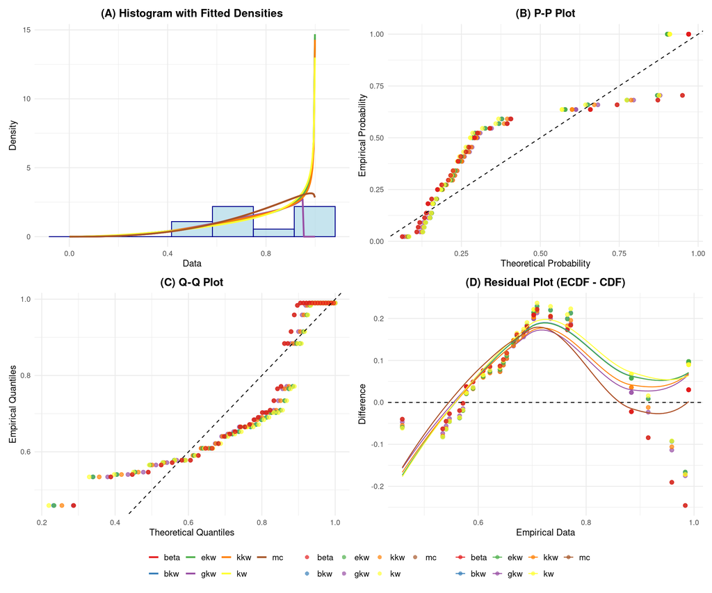

## Best Model Details

The kw model was identified as the best fit for the data, based on the AIC criterion.

|  | Parameter | Estimate | Standard Error | z-value | p-value |
| --- | --- | --- | --- | --- | --- |
| alpha | alpha | 2.6832 | 0.5866 | 4.5739 | 0 |
| beta | beta | 0.6642 | 0.1203 | 5.5194 | 0 |

## Conclusions

Based on the analysis results, we can conclude that:

1. The kw model provides the best fit to the data among all GKw family distributions considered.
2. This model had the lowest AIC value (-49.1) and an AIC weight of 0.4877.
3. The goodness-of-fit tests indicate some discrepancies between the theoretical model and the observed data.

The diagnostic visualizations show that the kw model may not adequately capture the behavior of the data, especially in the central region of the distribution.

## Recommendations

1. For statistical modeling of this data, we recommend using the kw distribution.
2. This model offers a good balance between fit and parsimony.
3. For applications requiring high precision in distribution tails, it may be necessary to explore other distribution families beyond GKw.

## References

1. Kumaraswamy, P. (1980). A generalized probability density function for double-bounded random processes. Journal of Hydrology, 46(1-2), 79-88.
2. Cordeiro, G. M., & de Castro, M. (2011). A new family of generalized distributions. Journal of Statistical Computation and Simulation, 81(7), 883-898.
3. Kristensen, K., Nielsen, A., Berg, C. W., Skaug, H., & Bell, B. M. (2016). TMB: Automatic Differentiation and Laplace Approximation. Journal of Statistical Software, 70(5), 1-21.